# R Project Assignment

Odessa Zang

November 27, 2023

## Question 1

```r
Coin.Throw<-sample(c('H', 'T'), 100, replace=TRUE) ##Generates a sequence of 100 random coin tosses, stores the data in the variable 'Coin.Throw'
Coin.Throw ##Prints out the results in the console
```

```
##   [1] "T" "T" "T" "H" "H" "T" "T" "T" "H" "H" "H" "H" "T" "T" "H" "H" "H" "T"
##  [19] "T" "H" "T" "H" "T" "T" "H" "H" "H" "T" "T" "H" "H" "H" "T" "T" "H" "H"
##  [37] "T" "H" "T" "T" "H" "H" "H" "T" "H" "T" "H" "H" "H" "H" "T" "T" "T" "T"
##  [55] "H" "H" "H" "H" "T" "H" "T" "T" "H" "T" "T" "T" "H" "H" "H" "T" "T" "T"
##  [73] "H" "H" "H" "T" "T" "H" "H" "H" "T" "T" "T" "T" "T" "T" "H" "H" "T" "T"
##  [91] "H" "T" "T" "H" "T" "H" "H" "T" "H" "H"
```

```r
table(Coin.Throw) ##Creates a table showing the counts from the toss
```

```
## Coin.Throw
##  H  T
## 51 49
```

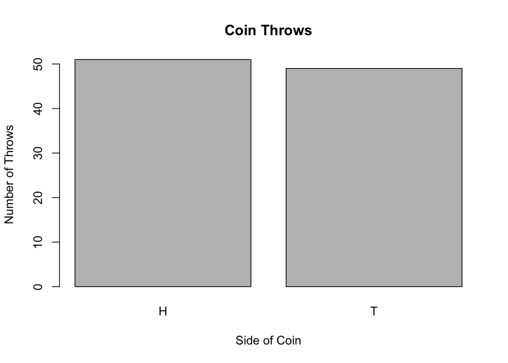

```r
barplot(table(Coin.Throw), ylab = "Number of Throws", xlab = "Side of Coin", main = "Coin Throws") ##Creates a bar plot with the data, a title and labels have been added
```

## Question 2

```r
CoinThrow2<-sample(c(0, 1), 100, replace=TRUE) ##Generates a sequence of 100 random coin flips with replacement.
CoinThrow2 ##Prints out the sequence in the console.
```

```
##   [1] 0 1 1 0 0 1 1 1 0 0 1 1 1 0 0 1 1 0 1 1 0 1 0 0 0 0 0 0 0 0 0 0 1 1 0 0 0
##  [38] 1 0 0 0 1 1 1 1 1 0 0 1 0 0 1 0 0 1 0 1 1 0 0 1 0 0 1 1 1 1 0 1 1 1 1 0 0
##  [75] 1 0 1 0 0 0 0 1 1 0 1 1 1 1 0 0 0 0 1 0 1 0 0 0 1 0
```

```r
cumsum(CoinThrow2) ##Calculates the cumulative sum of the sequence.
```

```
##   [1]  0  1  2  2  2  3  4  5  5  5  6  7  8  8  8  9 10 10 11 12 12 13 13 13 13
##  [26] 13 13 13 13 13 13 13 14 15 15 15 15 16 16 16 16 17 18 19 20 21 21 21 22 22
##  [51] 22 23 23 23 24 24 25 26 26 26 27 27 27 28 29 30 31 31 32 33 34 35 35 35 36
##  [76] 36 37 37 37 37 37 38 39 39 40 41 42 43 43 43 43 43 44 44 45 45 45 45 46 46
```

```r
table(CoinThrow2) ##Creates a table with the counts of each flip in the sequence.
```

```
## CoinThrow2
##  0  1
## 54 46
```

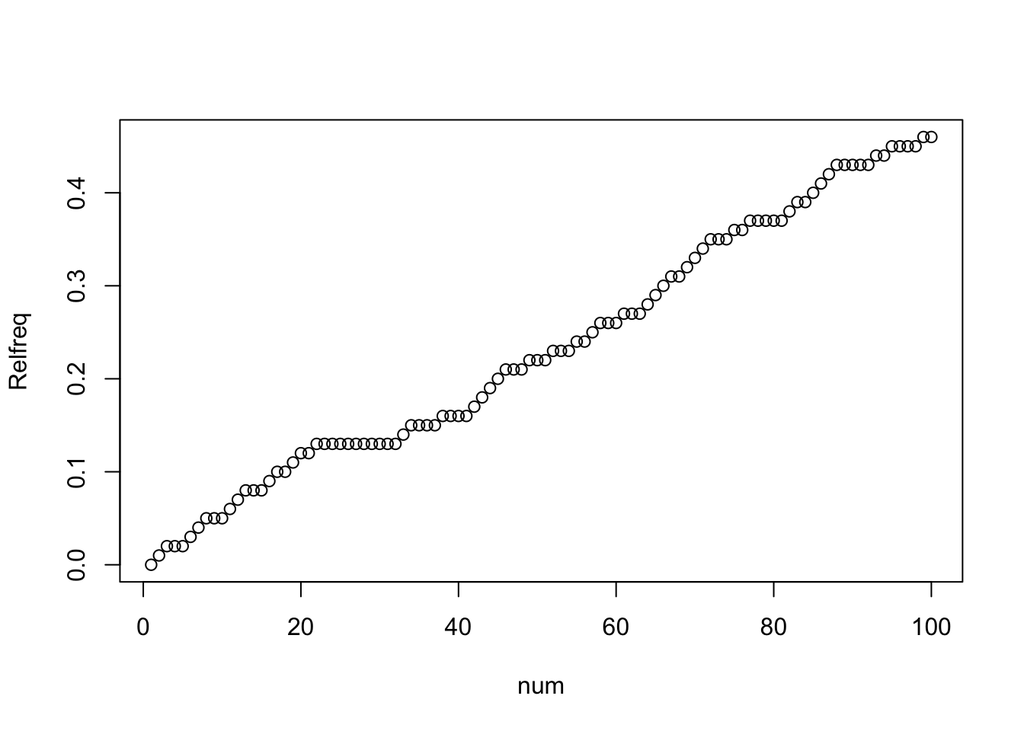

```r
Relfreq<-cumsum(CoinThrow2)/length(CoinThrow2) ##Calculates the relative frequency of the cumulative sum.
num<-1:100 ##Generates a sequence of numbers from 1 to 100.
plot(num, Relfreq) ##Creates a line plot of the relative frequency.
```

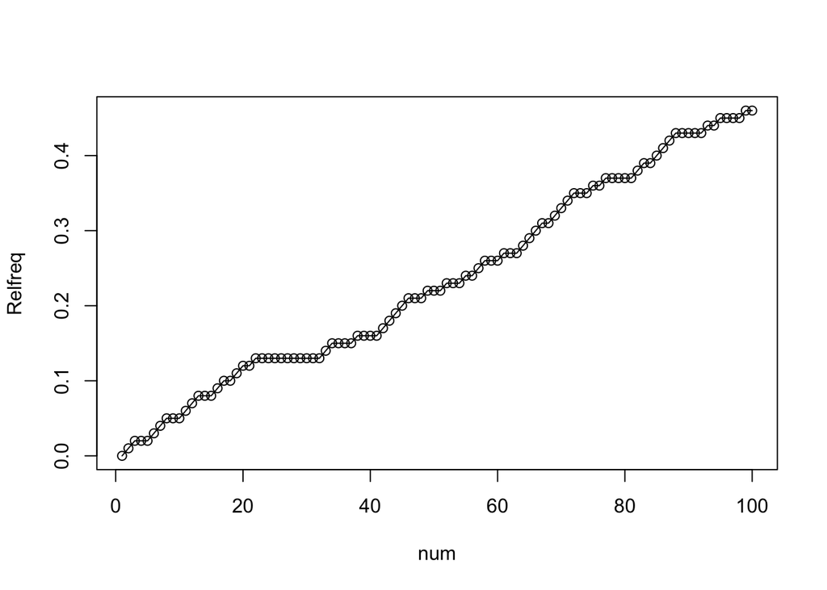

```r
plot(num, Relfreq, type="o") ##Creates a line plot of the relative frequency with marked points.
```

## Question 3

```r
CoinThrow3<-sample(c(1,0), 100, replace = TRUE) ##1 represents a head and 0 represents a tail.
CoinThrow3 ##Displays the number of tosses.
```

```
##   [1] 1 0 1 1 1 0 0 0 1 0 0 1 1 0 1 1 1 1 0 0 1 1 1 1 1 1 0 0 1 1 1 0 0 1 0 0 1
##  [38] 0 1 1 0 1 0 1 0 0 1 0 0 0 0 0 1 1 1 1 0 1 1 1 0 1 1 0 0 0 1 1 0 1 0 1 0 0
##  [75] 0 0 1 0 0 1 0 0 1 1 1 0 0 0 1 1 1 1 0 0 1 0 0 1 1 0
```

```r
table(CoinThrow3) ##Creates a table of the outcomes.
```

```
## CoinThrow3
##  0  1
## 48 52
```

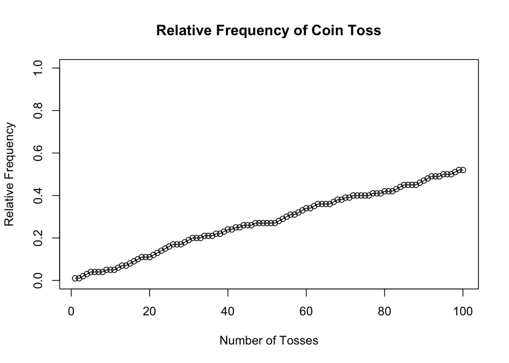

```r
Relfreq2<-cumsum(CoinThrow3)/length(CoinThrow3) ##Calculates the relative frequency of the cumulative sum.
num2<-1:100 ##Generates a sequence of numbers from 1 to 100
plot(num2, Relfreq2, type="o",ylim = (c(0,1)),xlab = "Number of Tosses", ylab = "Relative Frequency", main = "Relative Frequency of Coin Toss") ##Creates a line plot of the relative frequency with marked points.
```

## Question 4

```r
library(readxl)
mydata1<-read_xlsx("TitanicDataA5.xlsx")
head(mydata1)
```

```
## # A tibble: 6 × 5
##   Name                                               Sex    Age   Pclass   Fate
##   <chr>                                              <chr>  <chr> <chr>    <chr>
## 1 Mr. Owen Harris Braund                             Male   18-30 3rd Cla… Died
## 2 Mrs. John Bradley (Florence Briggs Thayer) Cumings Female 31-60 1st Cla… Surv…
## 3 Miss. Laina Heikkinen                              Female 18-30 3rd Cla… Surv…
## 4 Mrs. Jacques Heath (Lily May Peel) Futrelle        Female 31-60 1st Cla… Surv…
## 5 Mr. William Henry Allen                            Male   31-60 3rd Cla… Died
## 6 Mr. James Moran                                    Male   18-30 3rd Cla… Died
```

```r
names(mydata1)
```

```
## [1] "Name"   "Sex"    "Age"    "Pclass" "Fate"
```

```r
Twoway_a<-table(mydata1$Fate, mydata1$Age)
Twoway_a
```

```
##
##            17 & Below 18-30 31-60 60 Above
##   Died             65   263   196       21
##   Survived         65   132   140        5
```

```r
Twoway_b<-table(mydata1$Fate, mydata1$Sex)
Twoway_b
```

```
##
##            Female Male
##   Died         81  464
##   Survived    233  109
```

```r
Twoway_c<-table(mydata1$Fate, mydata1$Pclass)
Twoway_c
```

```
##
##            1st Class 2nd Class 3rd Class
##   Died            80        97       368
##   Survived       136        87       119
```

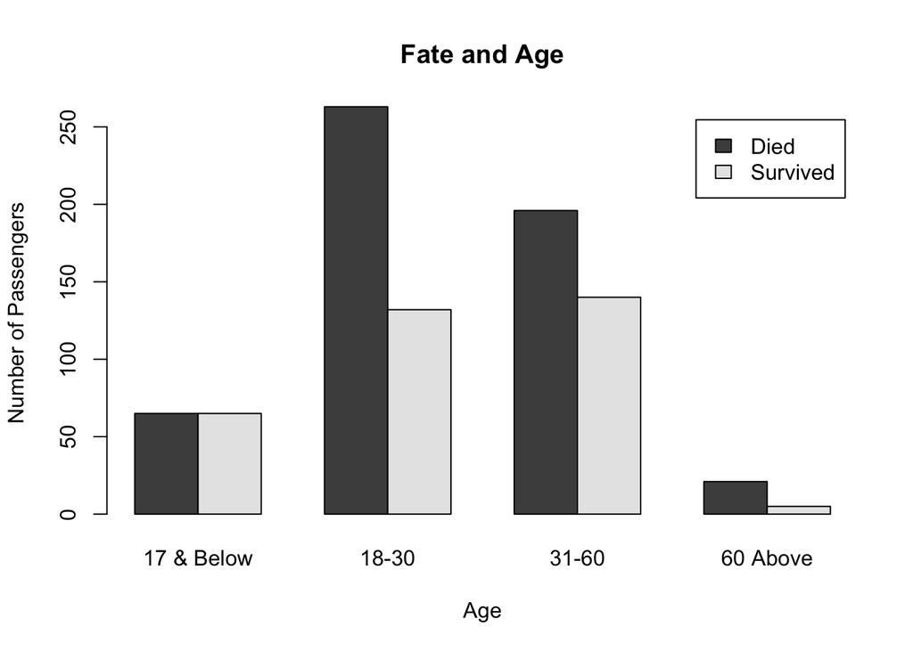

```r
barplot(Twoway_a, beside = TRUE, legend.text = rownames(Twoway_a), xlab = "Age", ylab = "Number of Passengers", main = "Fate and Age")
```

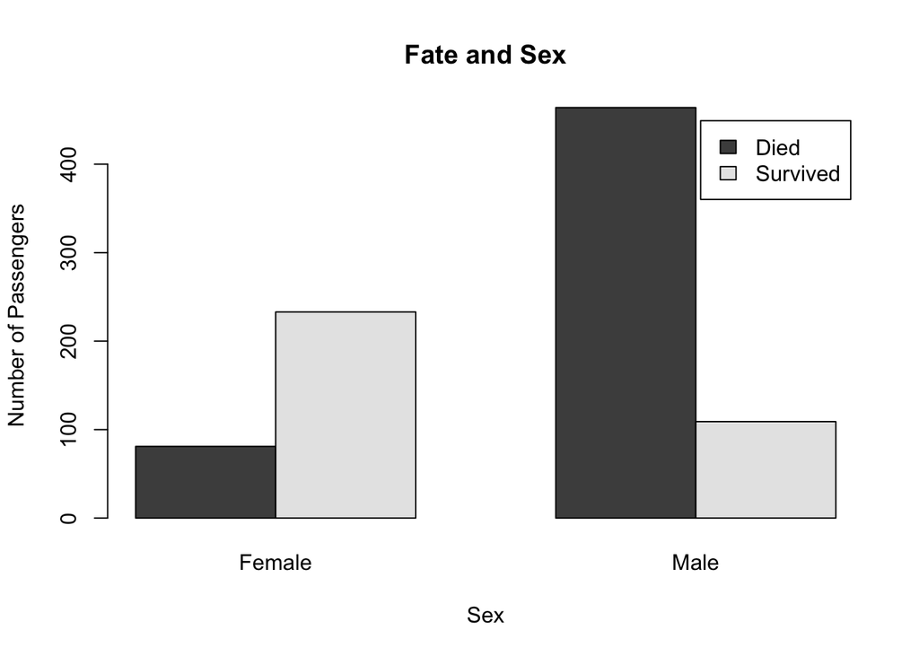

```r
barplot(Twoway_b, beside = TRUE, legend.text = rownames(Twoway_b), xlab = "Sex", ylab = "Number of Passengers", main = "Fate and Sex")
```

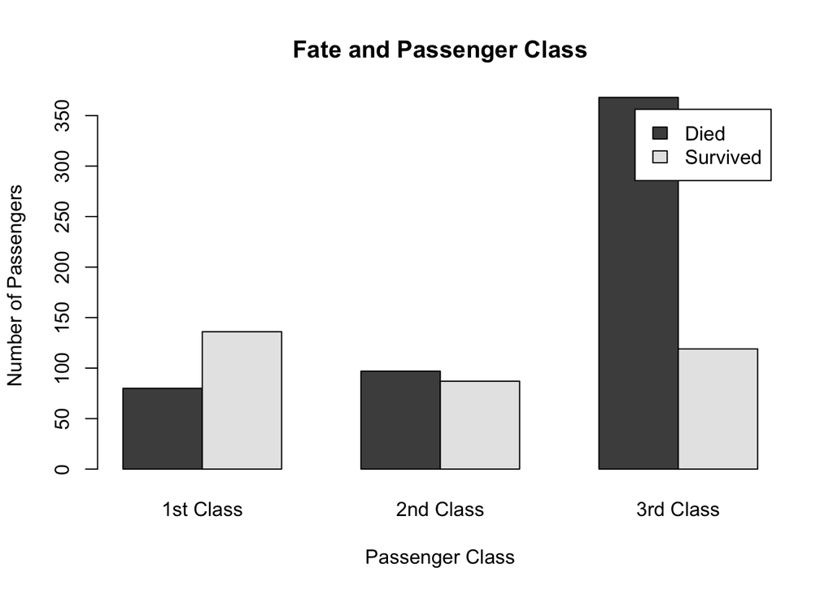

```r
barplot(Twoway_c, beside = TRUE, legend.text = rownames(Twoway_c), xlab = "Passenger Class", ylab = "Number of Passengers", main = "Fate and Passenger Class")
```

```r
prob_a<-Twoway_a/sum(Twoway_a)
signif(prob_a,2)
```

```
##
##            17 & Below  18-30  31-60 60 Above
##   Died         0.0730 0.3000 0.2200   0.0240
##   Survived     0.0730 0.1500 0.1600   0.0056
```

```r
prob_b<-Twoway_b/sum(Twoway_b)
signif(prob_b,2)
```

```
##
##            Female  Male
##   Died      0.091 0.520
##   Survived  0.260 0.120
```

```r
prob_c<-Twoway_c/sum(Twoway_c)
signif(prob_c,2)
```

```
##
##            1st Class 2nd Class 3rd Class
##   Died         0.090     0.110     0.410
##   Survived     0.150     0.098     0.130
```

From the probabilities calculated above, those who were in 1st class, female and aged 17 and below were more likely to survive the Titanic incident.

## Question 5

1. In the height column, some of the height are written in feet and inches, one has no height written and another has the unit written although it is included in the header.
2. In the foot length column, one of the lengths is missing a decimal point, two lengths have the unit written in although it is included in the header, and there are two lengths missing
3. In home occupants, ‘4+dog’ should just be 5.

```r
library(readxl)
library(psych)
mydata2<-read_xlsx("ChildDataB52.xlsx")
names(mydata2)
```

```
##  [1] "Grade"           "Height"          "Footlength"      "Age"
##  [5] "Sex"             "Domhand"         "FavSchSubject"   "HomeOccupants"
##  [9] "SchWorkPressure" "PlannedQual"     "Preferred2be"
```

```r
Two_a<-table(mydata2$Sex, mydata2$Domhand)
Two_a
```

```
##
##          Left-Handed Right-Handed
##   Female           4           13
##   Male             3           20
```

```r
Two_b<-table(mydata2$Sex, mydata2$SchWorkPressure)
Two_b
```

```
##
##          A lot None Some Very little
##   Female     7    0    7           3
##   Male       3    1   12           7
```

```r
Two_c<-table(mydata2$Sex, mydata2$Preferred2be)
Two_c
```

```
##
##          Famous Happy Healthy Rich
##   Female      1    10       3    3
##   Male        1    10       4    8
```

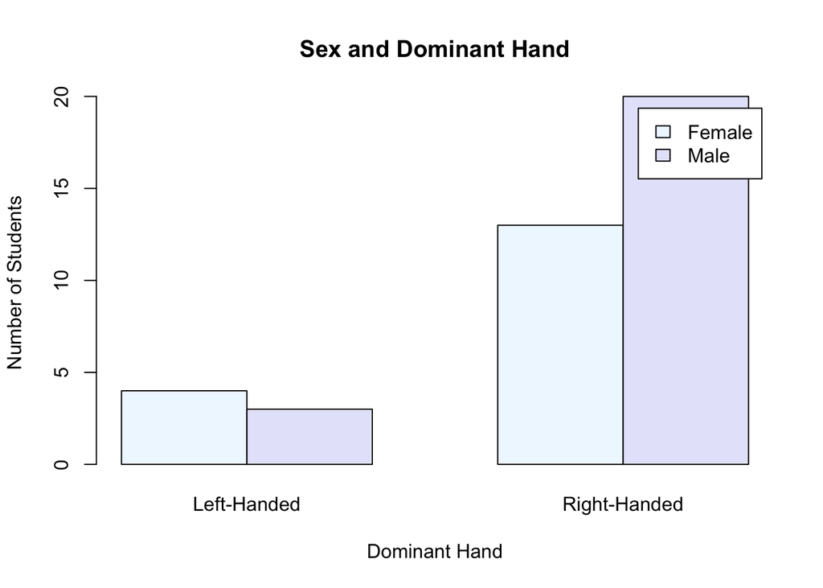

```r
barplot(Two_a, col = c("aliceblue","lavender"), beside = TRUE, legend.text = rownames(Two_a), xlab = "Dominant Hand", ylab = "Number of Students", main = "Sex and Dominant Hand")
```

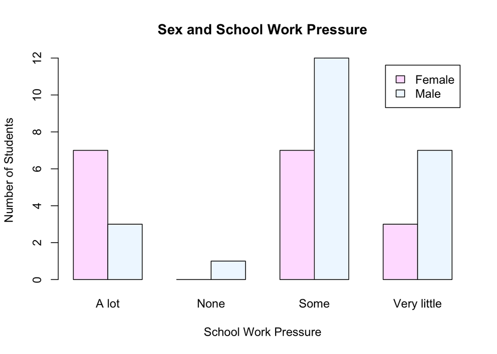

```r
barplot(Two_b, col = c("thistle1", "aliceblue"), beside = TRUE, legend.text = rownames(Two_b), xlab = "School Work Pressure", ylab = "Number of Students", main = "Sex and School Work Pressure")
```

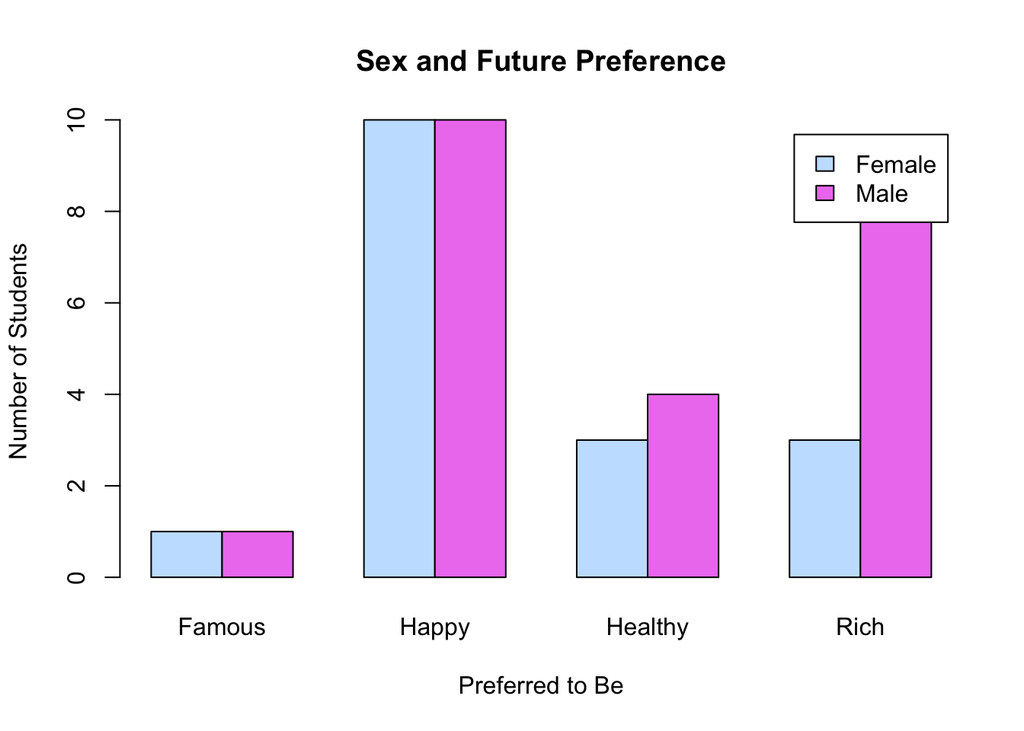

```r
barplot(Two_c, col = c("slategray1", "violet"), beside = TRUE, legend.text = rownames(Two_c), xlab = "Preferred to Be", ylab = "Number of Students", main = "Sex and Future Preference")
```

```r
describe(mydata2[, 2:4])
```

```
##            vars  n   mean    sd median trimmed   mad min max range  skew
## Height        1 40 164.85 25.47    170  169.19 11.12  63 200   137 -2.81
## Footlength    2 40  24.61  3.26     25   24.80  2.97  12  30    18 -1.20
## Age           3 40  16.30  1.44     17   16.50  1.48  12  18     6 -1.28
##            kurtosis   se
## Height         8.59 4.03
## Footlength     3.51 0.52
## Age            1.06 0.23
```

From the graphs above: It can be seen that more students are right handed than left handed and majority of right handed students male. Majority of male students have some school work pressure while more female students experience a lot of school stress. Most of the male and female students prefer to be happy.

From the descriptive statistics, the standard errors provided give more precision for the calculated means and the height variable has a higher kurtosis.